# Final_Project

Author

Rachel Bittner

#GitHub Repo:

https://github.com/bittnation/ENVS_193DS_Final

```r
library(tidyverse) #general
library(janitor) #cleaning data
library(ggplot2) #making plots
library(dplyr)
# reading in basic packages
library(DHARMa) #checking diagnostics
library(MuMIn) #using Akalie's Info. Criterion
library(ggeffects) #model predictions
library(gtsummary) #viewing gt summary tables
#reading in other necessary packages

# read in data sets
sst <- read.csv("Data/SST_SB.csv")

nest_boxes <- read.csv("Data/occdist.csv")
```

# Problem 1. Research Writing

1. In part 1, they used Pearson’s correlation. The key word “correlation” suggest that they either performed a Pearson’s correlation test or Spearman’s rho. Since kg year-1 and km are both continuous variables instead of rankings it is likely Pearson’s r. In part 2, they used a one-way ANOVA. The key phrase “difference in average” indicates ANOVA which aims to compare the means (averages) of more than one group. The type of ANOVA was determined by the number of groups, the results indicated the comparison of more than three groups which requires a one-way ANOVA.
2. To add more context to the results, my coworker should provide a Tukey’s Honestly significant Difference and key ANOVA statistics. It is important to include Tukey’s HSD because it provides context as to which of the 6 groups were actually different from each other. This is test is important because it prevents Type I errors. Include key ANOVA statistics such as test type, F-value, degrees of freedom, and significance level to strengthen the statistical results. It aids readers ability to interpret data and draw conclusions and it promotes transparency and reduces skeptism, the p-value doesn’t tell the whole story so it is important to communicate all statistical results.
3. ANOVA statistics: We found that there was a significant difference in average nitrogen load (kg year-1) between sources (urban land, atmospheric deposition, fertilizer, waste water treatment, and grasslands) (one-way ANOVa, F(df among groups, df withing groups),p = 0.02, α = significance level). Tukey’s HSD: On Average, urban land tended to have [higher or lower] nitrogen loads (kg year-1) than grasslands ( _ kg year-1 (higher or lower), _ % CI: [x:y] kg year-1) and fertilizer (_ kg year-1 (higher or lower), _ % CI: [x:y] kg year-1 )…

# Problem 2. Data Visualization

```r
sst_clean <- sst |>
  clean_names() |> #cleans column names
  mutate(
    date = ymd(date),
    year = year(date),
    month = month(date, label = TRUE, abbr = TRUE)
          ) |> #making a separate column with just the year and another with just the month (month is converted from numeric to abbreviated version)

 #filter to only include data from years of interst

 filter(year %in% c("2018", "2019", "2020", "2021", "2022", "2023")) |>


 # remove date (ymd) format, site, latitude, longitude,

select(!c(date, site, latitude, longitude))

sst_clean |> #displaying 5 random rows of cleaned data
  slice_sample(n = 5)
```

```
   temp year month
1 18.42 2022   Aug
2 17.51 2023   Aug
3 18.99 2020   Jul
4 16.56 2020   Jun
5 16.74 2021   Jun
```

```r
str(sst_clean) #displaying table
```

```
'data.frame':   41553 obs. of  3 variables:
 $ temp : num  14.4 14.6 14.9 15.2 15.6 ...
 $ year : num  2018 2018 2018 2018 2018 ...
 $ month: Ord.factor w/ 12 levels "Jan"<"Feb"<"Mar"<..: 1 1 1 1 1 1 1 1 1 1 ...
```

```r
#create summary data set using clean data

sst_summary <- sst_clean |>
#group so that we can find the months mean in its individual year
  group_by(year, month) |>
# re order data
    mutate(month = as_factor(month),
         month = fct_relevel(
           month,
           "Jan", "Feb", "Mar", "Apr", "May", "Jun", "Jul", "Aug", "Sep", "Oct", "Nov", "Dec")
         ) |> #months in correct calender order
  mutate(year = as_factor(year)) |> #making data categorical instead of numerical

#summarize mean sst
  summarize(
    mean_monthly_sst = mean(temp),
    .groups = "drop" #removing extra info for structure
    )
sst_summary #display summary
```

```
# A tibble: 72 × 3
   year  month mean_monthly_sst
   <fct> <ord>            <dbl>
 1 2018  Jan               15.0
 2 2018  Feb               14.3
 3 2018  Mar               13.5
 4 2018  Apr               12.8
 5 2018  May               13.6
 6 2018  Jun               15.5
 7 2018  Jul               18.2
 8 2018  Aug               19.6
 9 2018  Sep               18.2
10 2018  Oct               18.5
# ℹ 62 more rows
```

```r
str(sst_summary)
```

```
tibble [72 × 3] (S3: tbl_df/tbl/data.frame)
 $ year            : Factor w/ 6 levels "2018","2019",..: 1 1 1 1 1 1 1 1 1 1 ...
 $ month           : Ord.factor w/ 12 levels "Jan"<"Feb"<"Mar"<..: 1 2 3 4 5 6 7 8 9 10 ...
 $ mean_monthly_sst: num [1:72] 15 14.3 13.5 12.8 13.6 ...
```

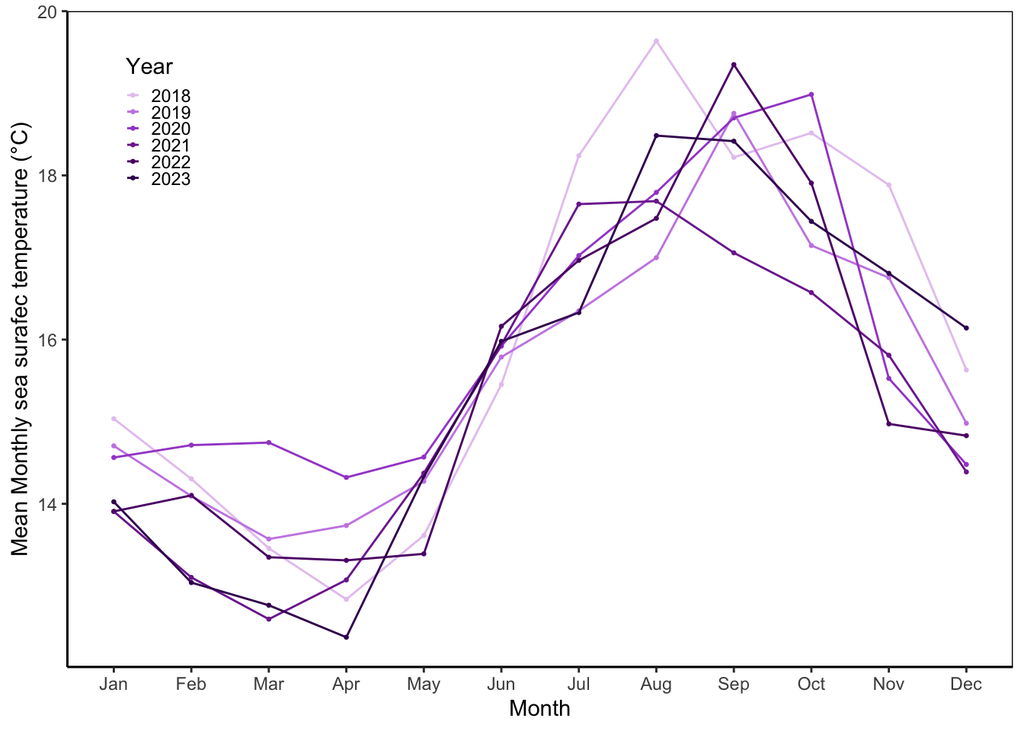

```r
# creating plot using cleaned sst data set
sst_plot <- ggplot(data = sst_summary,
   aes(x = month, #setting month as x-axis
       y = mean_monthly_sst, #setting mean sst on y-axis
       color = year, #coloring by year
       group = year #connecting lines between groups
   )) +
  geom_point(size =0.5) + #setting point size
  geom_line()+ #line plot
  labs( #labels
    x = "Month",
    y = "Mean Monthly sea surafec temperature (°C)",
    color = "Year" #labeling legend
  ) +
  theme_classic() + #setting classic theme
  theme(legend.position = c(0.05, 0.95), # position inside plot
  legend.justification = c(0, 1),# position legend in top-left corner
  legend.key.size = unit(0.25, "cm"), #making legend visable
  panel.border = element_rect(color = "black", fill = NA, linewidth = 0.5)) + #creating panel boarder
scale_color_manual(
values = c(
"2018" = "#E6C8F0",
"2019" = "#C989E5",
"2020" = "#A44FCF",
"2021" = "#7E2C9E",
"2022" = "#5E1675",
"2023" = "#3E065F"
)) #coloring lines from light to dark
sst_plot # view plot
```

# Problem 3. Data Analysis

1. The “1’s” and “0’s” in this data set represent occupancy of nest boxes. If “sp” is 1, that indicates that the box is occupied by swift parrots, if not occupied or occupied by a non target species”sp” is 0. Of the four occupation options: “sp”, “cs”, “e”, and “tm” each box will only have one “1” and the other three will be “0’s”
2. In the context of this study the main difference between Swift Parrots and the other species, Common Starling and Tree Martin, is that Swift Parrots are critically endangered making them at risk to extinction. Providing a safe place to facilitate and encourage the successful breeding on Swift Parrots could be crucial in helping the species population recover.
3. Defining the year as seasons is important in the context of this study because when the boxes were initially installed in 2016 there were no previous occupant therefore there were more open boxes. However in 2019 many boxes were already occupied by non-target species when Swift Parrots arrive for mating season.

| Model number | Season | Distance to forest edge | Description |
| --- | --- | --- | --- |
| 0 |  |  | No predictors (null model) |
| 1 | X | X | Season, Distance to forest edge |
| 2 | X |  | Season |
| 3 |  | X | Distance to forest edge |

```r
#remove all data that is not used in model predictions
nest_boxes_clean <- nest_boxes |>
    clean_names() |> #replacing spaces with underscores
#remove box, box occupant, event ID, and, repeated use
select(!c(box, box_occupant, event_id,repeated_use))
```

```r
# model 0: null model
model0 <- lm(
  sp ~ 1, # presence of sp as response variable
  data = nest_boxes_clean) # data frame)

# model 1: all predictors
model1 <- lm(
  sp ~ edge_distance + season, # edge distance and season as predictor
  data = nest_boxes_clean )# data frame)

# model 2: Season
model2 <- lm(
  sp ~ season,#season as predictor
  data = nest_boxes_clean)

# model 3: Distance to forest edge
model3 <- lm(
  sp ~ edge_distance, #edge distance as predictor
  data = nest_boxes_clean)
```

```
hat values (leverages) are all = 0.004405286
 and there are no factor predictors; no plot no. 5
```

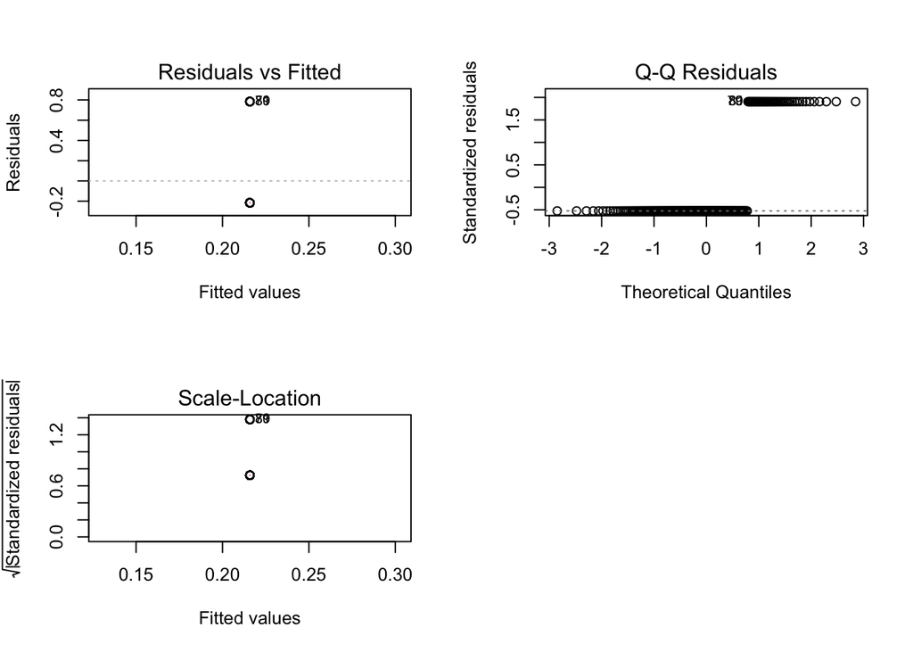

```r
par(mfrow = c(2,2))
plot(model0)
```

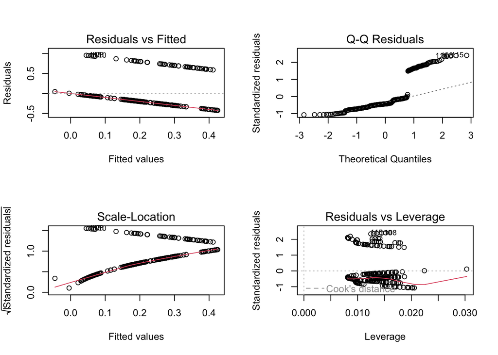

```r
plot(model1)
```

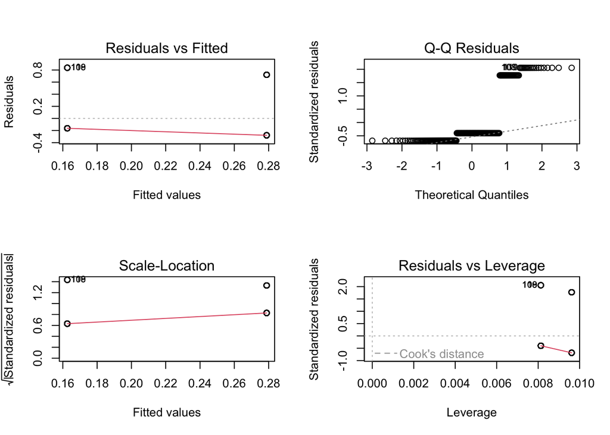

```r
plot(model2)
```

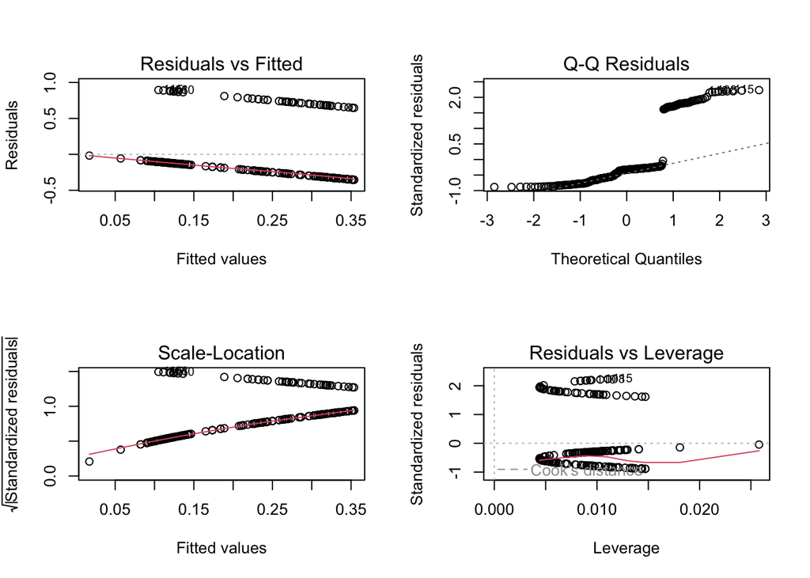

```r
plot(model3)
```

7. The best model as determined by Akaike’s Information Criterion (AIC), selecting the saturated model predicting both edge distance and season as strong predictors of Swift Parrot presence in nest boxes.

```r
AICc(model0,
     model1, #best model: edge distance + season        (saturated)
     model2,
     model3) |>
  # arranging output in descending order of AIC
  arrange(AICc)
```

```
       df     AICc
model1  4 232.5485
model3  3 235.9030
model2  3 242.5425
model0  2 245.0324
```

```r
model1_predictions <- ggpredict(
  model1, # model object
  terms = c("edge_distance", "season") # predictors
) |>
  # treating this like a regular data frame
  # renaming the columns in predictions data set
  rename(edge_distance = x,
         season = group)

 #viewing new predictions data set
```

```r
nest_boxes_clean$season <- as.factor(nest_boxes_clean$season)
model1_predictions$season <- as.factor(model1_predictions$season)
```

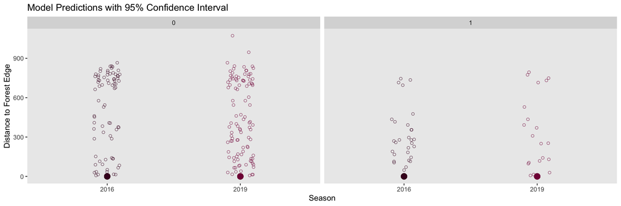

```r
# base layer: ggplot
# using the clean nest data as object
ggplot(data = nest_boxes_clean,
       aes(x = season, #x axis as season
           y = edge_distance,# y-axis as edge distance
           color = season)) + #coloring by season (2016 or 2019)
  # first layer: jitter showing individual observations
  geom_jitter(width = 0.1,
              height = 0,
              shape = 21,
              alpha = 0.6) +
  # second layer: point range showing model predictions
  # in the final model
  geom_pointrange(data = model1_predictions, #using data generated by model predictions
                  aes(x = season,
                      y = predicted,
                      ymin = conf.low, #including 95% CI
                      ymax = conf.high,
                      color = season),
                  position = position_dodge(width = 0.3),
                  size = 0.7 ) + #spreading apart observations for visual clarity
  # setting colors non default colors
  scale_color_manual(values = c("2016" = "#440525",
                                "2019" = "#820745")) +

  # creating different panels sp or empty/ non target species
  facet_wrap(~sp, nrow = 1) +
  # labelling x-, y-axis, and creating title
  labs(x = "Season",
       y = "Distance to Forest Edge",
       title = "Model Predictions with 95% Confidence Interval") +
  # taking out the legend and grid lines
  theme(legend.position = "none") +
  theme(panel.grid = element_blank())
```

1. Figure 1. Predicted Distance to Forest Edge by Season: Model-predicted nest box distances to forest edge for occupied (1) and unoccupied (0) boxes in 2016 and 2019. Points show observations colored by year; dark points are predictions with 95% confidence intervals (not visible due to narrow width). Data Source: Stojanovic, Dejan et al. (2021). Do nest boxes breed the target species or its competitors? A case study of a critically endangered bird [Dataset]. Dryad. https://doi.org/10.5061/dryad.83bk3j9sb

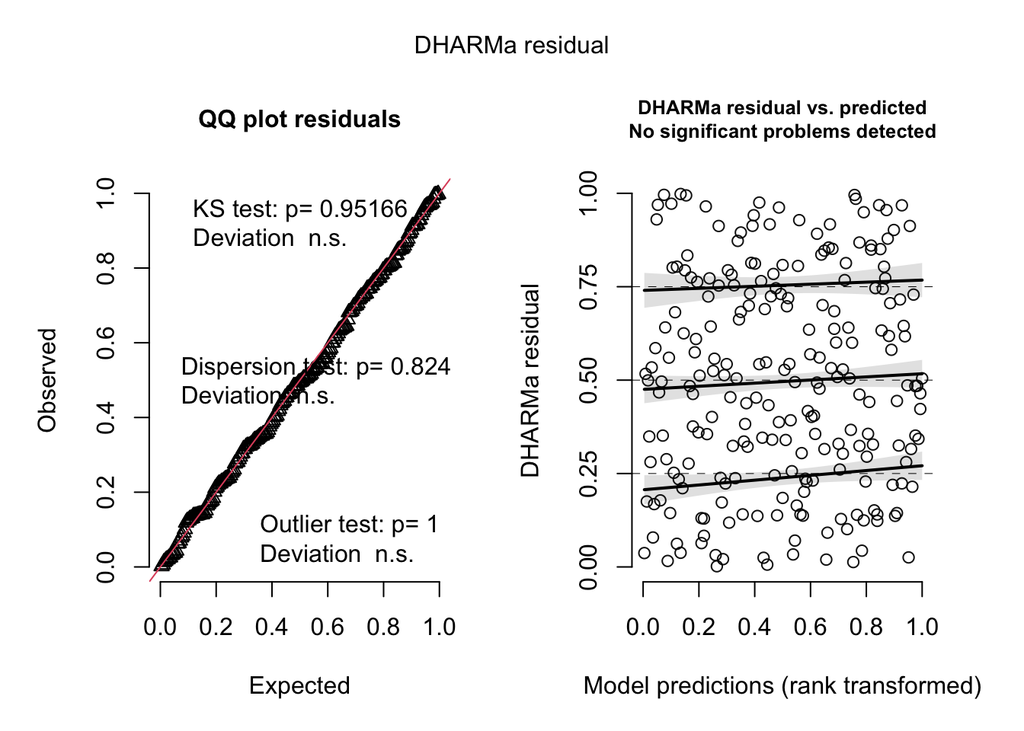

```r
#writing model that predicts occupancy based on edge for each season
nest_ocup_mod <- glm(sp ~ edge_distance + season,
                     data = nest_boxes_clean,
                     family = binomial)
#plotting residuals to look at diagnostics and asses model fit
plot(simulateResiduals(nest_ocup_mod))
```

```r
#displaying summary output to look at model coefficients
summary(nest_ocup_mod)
```

```
Call:
glm(formula = sp ~ edge_distance + season, family = binomial,
    data = nest_boxes_clean)

Coefficients:
                Estimate Std. Error z value Pr(>|z|)
(Intercept)   -0.0774902  0.3293209  -0.235 0.813974
edge_distance -0.0020782  0.0006226  -3.338 0.000843 ***
season2019    -0.7791985  0.3390296  -2.298 0.021544 *
---
Signif. codes:  0 '***' 0.001 '**' 0.01 '*' 0.05 '.' 0.1 ' ' 1

(Dispersion parameter for binomial family taken to be 1)

    Null deviance: 236.81  on 226  degrees of freedom
Residual deviance: 220.21  on 224  degrees of freedom
AIC: 226.21

Number of Fisher Scoring iterations: 4
```

```r
#creating regression table to interpret odds ratio
gtsummary ::tbl_regression(nest_ocup_mod,
                           exponentiate = TRUE)
```

| **Characteristic** | **OR** | **95% CI** | **p-value** |
| --- | --- | --- | --- |
| edge_distance | 1.00 | 1.00, 1.00 | <0.001 |
| season |  |  |  |
| 2016 | — | — |  |
| 2019 | 0.46 | 0.23, 0.89 | 0.022 |

Abbreviations: CI = Confidence Interval, OR = Odds Ratio

```r
# predicting probability of occupancy from forest edge (0m) to 900m from forest edge
ggpredict(nest_ocup_mod,
          terms = c("edge_distance [0,900]", "season"))
```

```
# Predicted probabilities of sp

season: 2016

edge_distance | Predicted |     95% CI
--------------------------------------
            0 |      0.48 | 0.33, 0.64
          900 |      0.12 | 0.06, 0.24

season: 2019

edge_distance | Predicted |     95% CI
--------------------------------------
            0 |      0.30 | 0.18, 0.44
          900 |      0.06 | 0.03, 0.13
```

11. Swift Parrots tend to occupy nest boxes more frequently when those boxes are located closer to the forest edge (see model summary table, part h; and predicted values, part j). With each 1-meter increase in distance from the forest edge, the odds of nest box occupancy decrease (OR = 1.0, 95% CI: [1.00, 1.00], p < 0.001 , α = 0.05). At the forest edge (0 m), the probability of occupancy is higher in both seasons, with predicted probabilities of 0.48 (95% CI:[0.33, 0.64]) in 2016 and 0.30 (95% CI:[0.18, 0.44]) in 2019. At 900 m from the forest edge, occupancy probabilities decrease substantially to 0.12 (95% CI:[0.06, 0.24]) in 2016 and 0.06 (95% CI:[0.03, 0.13]) in 2019. This trend suggest that Swift Parrots’ have a preference for edge habitat, this could be due to factors like food and resource availability.

# Problem 4. Affective and Exploratopry Visualizations

1. The way that the visualizations represent my data is very different. The exploratory visualizations from homework 2 were very simple, just a basic bar graph and linear regression. My affective visualization from homework 3 is a less obvious display of data, it is not interpret-able at first glance like my effective visualizations despite the data showing the same trends. The biggest similarity between my visualizations are the tends in data the trends visualized in my affective visualization are the same trends represented in my exploratory visualizations.The pattern of higher caffeine intake leading to higher productivity is displayed in both visualizations, along with the pattern of more hours of productivity in the library than at home. The only major differences is an increase in variables, my visualizations from homework 2 did not contain any observations from the “lab” category, but my affective visualization had lots of observations from the “lab” category showing trends of high productivity.Some of the feedback that I got during the week 9 workshop was to create an ombre effect with my colors that signify caffeine consumption. I attempted to apply this feedback, however since darker colors tend to be longer and lighter colors tend to be longer the data visualization no longer fit the screen in an asymmetric way and no longer showed the variation within my weeks so I decided not to implement this change.
2. I attended section on week 10 and shared my affective visualization.